# Writing Efficient R Code

Miao Cai

1/9/2019

# 1 Introduction

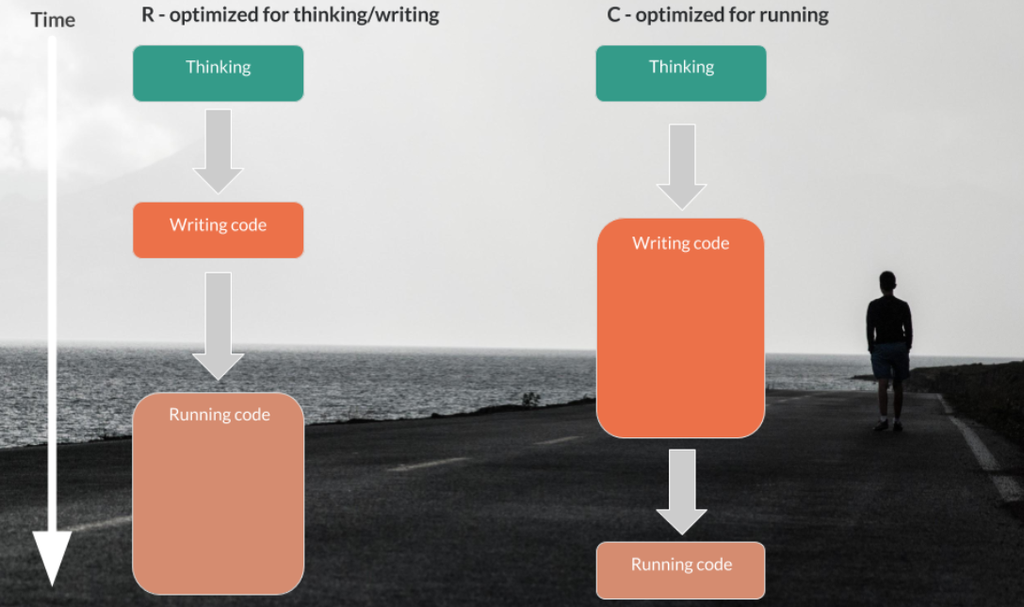

Comparing R and C

```r
knitr::include_graphics("RandC.png")
```

> Premature optimization is the root of all evil – by Donald Knuth

You should only optimize your code when necessary.

## 1.1 Keep your R version updated.

One of the relatively easy optimizations available is to use an up-to-date version of R. In general, R is very conservative, so upgrading doesn’t break existing code. However, a new version will often provide free speed boosts for key functions. The `version` command returns a list that contains (among other things) the major and minor version of R currently being used.

```r
# Print the R version details using version
version
```

```
##                _
## platform       x86_64-w64-mingw32
## arch           x86_64
## os             mingw32
## system         x86_64, mingw32
## status
## major          3
## minor          5.1
## year           2018
## month          07
## day            02
## svn rev        74947
## language       R
## version.string R version 3.5.1 (2018-07-02)
## nickname       Feather Spray
```

```r
# Assign the variable major to the major component
(major <- version$major)
```

```
## [1] "3"
```

```r
# Assign the variable minor to the minor component
(minor <- version$minor)
```

```
## [1] "5.1"
```

## 1.2 Benchmark

Timing with `system.time()`

- *user time*: the CPU time charged for the execution of user instructions
- *system time*: the CPU time charged for execution by the system on behalf of the calling process.
- *elapsed time*: approximately the sum of user and system time, which is ususally the time we care about.

```
library(microbenchmark)
set.seed(666)
n = 1e8
microbenchmark(
  colon(n),
  seq.default(n),
  seq_by(n)
)
```

`readRDS("data.rds)` is almost 10 times faster than `read.csv("data.csv)`

## 1.3 How good is your machine

```r
library("benchmarkme")
res = benchmark_std(runs = 3)
plot(res)
upload_results(res)
```

- SALUS windows computer: You are ranked 79 out of 82 machines.
- Macbook Pro 2018: You are ranked 63 out of 82 machines

For many problems your time is the expensive part. If having a faster computer makes you more productive, it can be cost effective to buy one. However, before you splash out on new toys for yourself, your boss/partner may want to see some numbers to justify the expense. Measuring the performance of your computer is called benchmarking, and you can do that with the `benchmarkme` package.

```r
(ram <- benchmarkme::get_ram())
```

```
## 6.44 GB
```

```r
(cpu <- benchmarkme::get_cpu())
```

```
## $vendor_id
## [1] "GenuineIntel"
##
## $model_name
## [1] "Intel(R) Xeon(R) CPU E5-1607 v2 @ 3.00GHz"
##
## $no_of_cores
## [1] 4
```

The benchmarkme package allows you to run a set of standardized benchmarks and compare your results to other users. One set of benchmarks tests is reading and writing speeds.

The function call

```r
res = benchmarkme::benchmark_io(runs = 1, size = 5)
```

```
## # IO benchmarks (2 tests) for size 5 MB:
```

```
##   Reading a csv with 625000 values: 1.14 (sec).
```

```
##   Writing a csv with 625000 values: 2.07 (sec).
```

# 2 Memory Allocation

In R

- Memory allocation happens automatically
- R allocate memory in RAM to store variables
- Minimize variable assignment for speed

## 2.1 Example

To create a sequence of numbers:

1. Sequecing: the obvious and best way:

```
x <- 1:n
```

2. Preallocating: not so bad:

```
x <- vector("numeric", n)
for (i in 1:n) {
  x[i] <- i
}
```

3. Growing: don’t ever do this (cardinal sin):

```
x <- NULL
for (i in 1:n) {
  x <- c(x, i)
}
```

> The first rule of R: never, ever grow a vector.

## 2.2 The importance of vectorizing your code

General rule:

- Calling an R function eventually leads to C or FORTRAN code
- This code very heavily optimized

Goal:

- Access the underlying C or FORTRAN codes as quickly as possible; the fewer functions call the better.

Vectorized functions

- Many R functions are vectorized
- single number but return a vector `rnorm(4)`
- vector as input `mean(c(36, 48))`

### 2.2.1 Looping and vectorizing

Allocation:

- Loop: One-off cost
- Vectorized: comparable

Generation:

- Loop: one million calls to `rnorm()` -Vectorized: a single call to `rnorm()`